# HW04

Chongdan Pan

2022/2/4

# Problem 1

### (a)

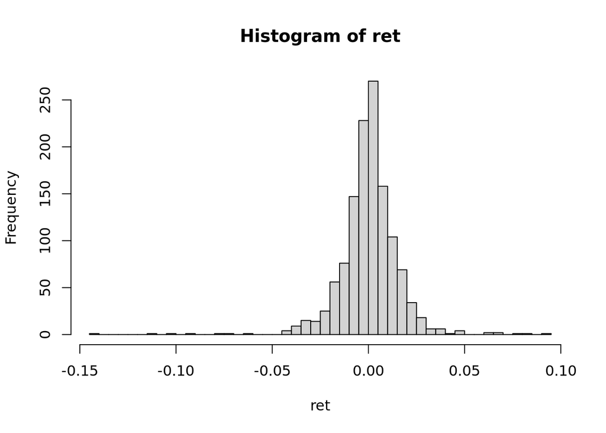

```r
df <- read.csv("../Rus2000_daily_Feb3_2017-Feb3_2022.csv", header=TRUE)
ret = df$Adj.Close[2:nrow(df)] / df$Adj.Close[1:nrow(df)-1] - 1
hist(ret, breaks=50)
```

The return seems to be symmetric to the 0, and it has a high kurtosis since there a lot of data in near 0, therefore it distribution may have a heavy tail although we don’t have a lot of samples with high absolute value.

### (b)

| median | mean | variance | skewness | kurtosis |
| --- | --- | --- | --- | --- |
| 0.0008414 | 0.0004222 | 0.0002433763 | -0.9844468 | 13.37257 |

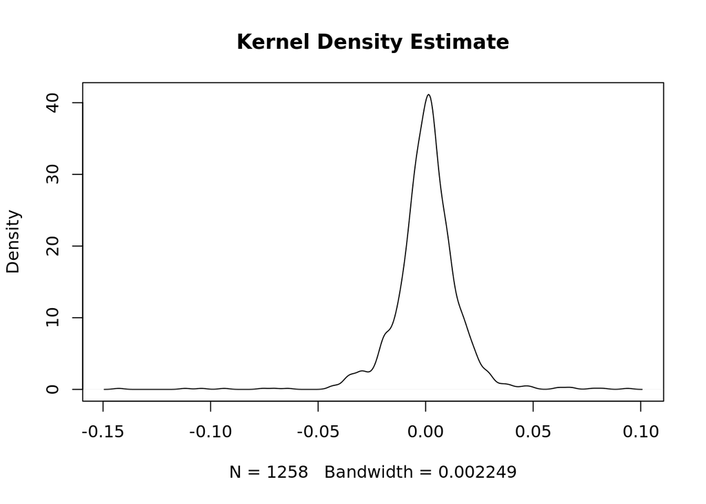

```r
plot(density(ret), main="Kernel Density Estimate")
```

### (c)

```r
-1e6 * qnorm(0.005, mean(ret), sd(ret))
```

```
## [1] 39762.09
```

Therefore, the VaR from normal distribution estimation is 39762.09 dollars

### (d)

```r
library(evir)
par(mfrow=c(2,2))
loss = -ret
eecdf = ecdf(loss)
plot(eecdf, main="ECDF of Loss", xlab="Claims", ylab="ECDF")
uv = seq(from = 0.025,to = 0.1, by = .001)
plot(uv,eecdf(uv), main="ECDF of Loss Tail", xlab="Claims", ylab="ECDF")
shape(loss, models=30, start=300, end=20, ci=0.9, reverse = TRUE, auto.scale=TRUE)
mu = 0.015
gpd_out = gpd(loss, threshold = mu)
gpd_out$par.ests
```

```
##         xi       beta
## 0.29026972 0.00885722
```

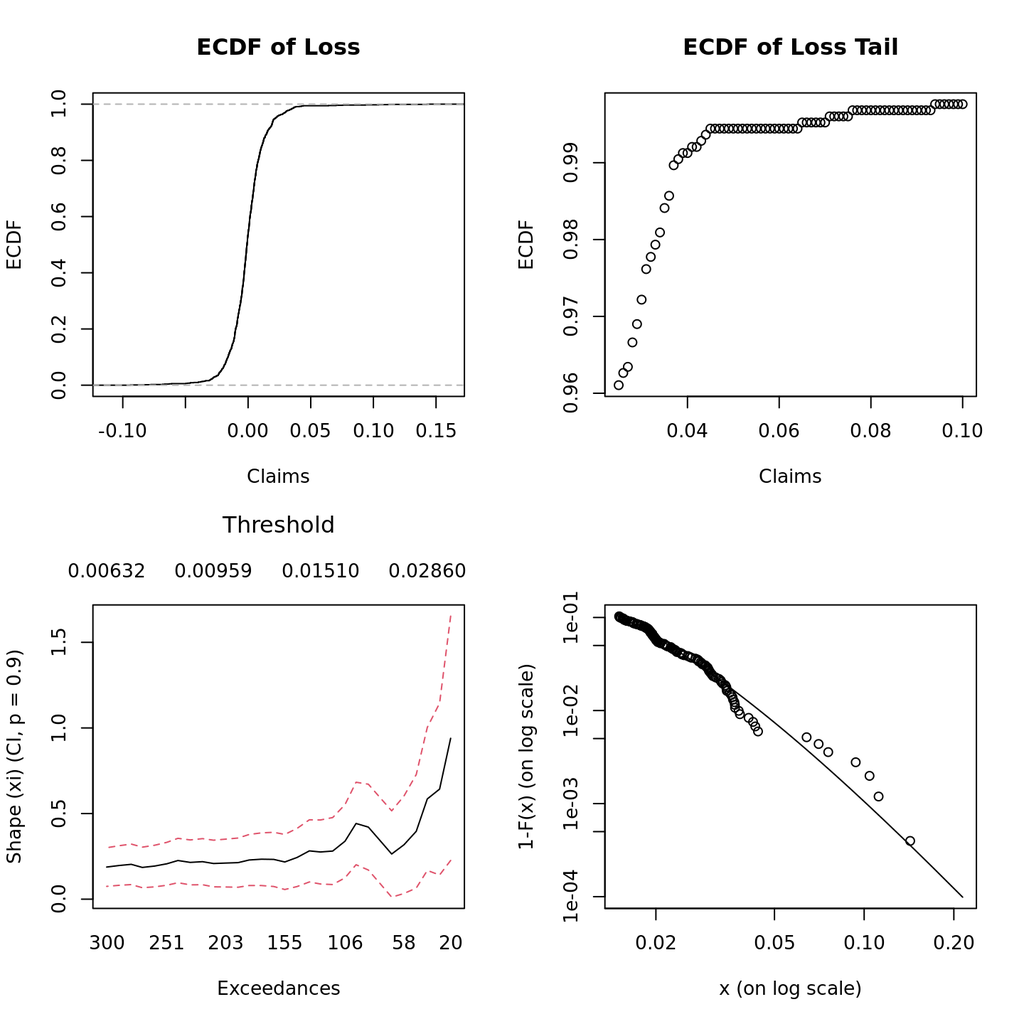

```r
tailplot(gpd_out)
```

It turns out when I set the threshold to be 0.015, the result from tail plot is linear, and the shape parameter is around 0.29

### (e)

```r
qt = 1-.005/(1-eecdf(mu))
xi = gpd_out$par.ests[1]
scale = gpd_out$par.ests[2]
VaR = qgpd(qt, xi, mu, scale)
1e6 * VaR
```

```
##    beta
## 57985.9
```

### (f)

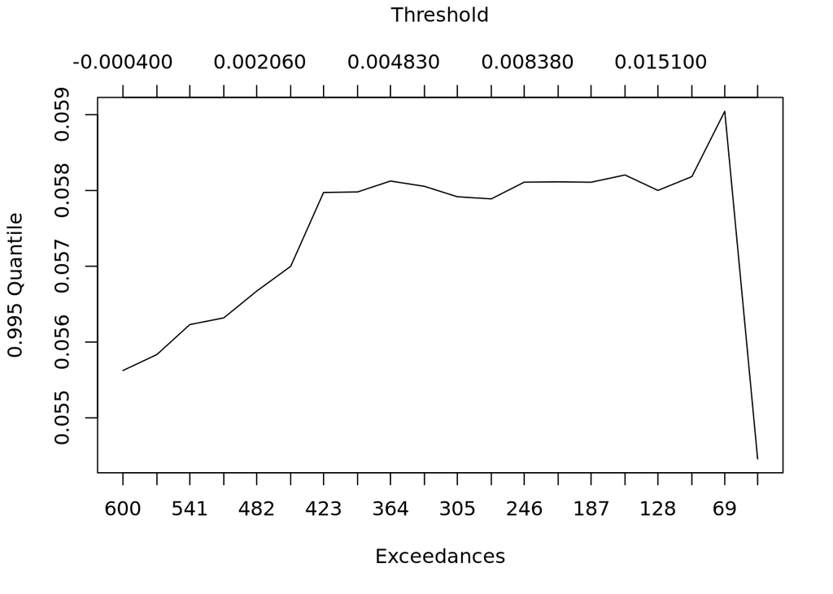

```r
quant(loss, p = 0.995, models = 20, start = 600, end = 40, reverse =TRUE, ci = FALSE, auto.scale = TRUE, labels = TRUE)
```

It turns out that the VaR is quite stable in the range from 0.003 to 0.018, and setting threshold to be 0.015 can work well for tail estimation.

### (g)

- For ES in part(c)

```r
1e6 * (mean(ret) + sd(ret) * dnorm(qnorm(0.005)) / 0.005)
```

```
## [1] 45538.1
```

The expected shortfall is 45538.1 dollars

- For ES in part(e)

```r
qt = 1-.005/(1-eecdf(mu))
xi = gpd_out$par.ests[1]
scale = gpd_out$par.ests[2]
1e6 * (VaR + (scale + xi * (VaR - mu)) / (1 - xi))
```

```
##     beta
## 88046.23
```

The expected shortfall is 88046.23 dollars

# 2

### (a)

$$COV[X,Y] = COV[X, X^2] = E[(X-E[X])(X^2 - E[X^2])]=E[X^3]=0$$

The covariance of $X$ and $Y$ is 0, so they’re not correlated. However, since $Y=X^2$, then they’re not independent.

### (b)

Based on the definition, we have
$$\hat\rho_S=\frac{12}{n(n^2-1)}[\sum_{i=0}^{\lfloor n/2\rfloor}(2*i + 1-\frac{n+1}{2})(n+1-n-1)-(\lfloor n/2\rfloor-\frac{n+1}{2})(1-\frac{n+1}{2})]
\\\hat\rho_S=0$$

### (c)

$$\text{Let}\quad w=\begin{bmatrix}x\\y\\z\end{bmatrix}
\\\text{Then}\quad Var(w^TY)=w^TCov(Y)w=x^2+y^2+z^2+1.8(xy+yz+axz)
\\\text{Assume}\quad a=0\quad\text{and}\quad x=z=1,y=-1.8
\\\text{Then}\quad Var(w^TY)=-1.24$$

```r
w = as.vector(c(1, -1.8, 1))
x =matrix(c(1, 0.9, 0, 0.9, 1, 0.9, 0, 0.9, 1), nrow=3, ncol=3)
t(w)%*%x%*%w
```

```
##       [,1]
## [1,] -1.24
```

Since the variance should be always larger than 0, then $a$ can’t be 0

### (d)

Since the matrix is covariance, then all its eigenvalues must greater than 0. To calculate the eigenvalues, we have

$$\begin{bmatrix}1-\lambda&0.9&a\\0.9&1-\lambda&0.9\\a&0.9&1-\lambda\end{bmatrix}=0
\\\text{Hence,it's determinant is}\quad(1-\lambda-a)[\lambda^2-(2+a)\lambda+a-0.62]=0
\\\text{Then we have three eigenvalues}\quad \lambda_1=1-a,\lambda_2=\frac{a+2+\sqrt{a^2+6.48}}{2},\lambda_3=\frac{a+2-\sqrt{a^2+6.48}}{2}
\\\text{Since all eigenvalues must be greater or equal to 0, we have }0.62\leq a\leq 1$$

Therefore, the lower limit on $a$ is 0.62